# R & R-Markdown

December 10, 2015

## Review & (brief) Outline

- Git/GitHub
- New questions?
- Collaborative tools to *centralize* your workflow.
- Extend on these concepts, as they relate to concepts in reproducibility
- Similar mindset as last-time: provide an overview, help demonstrate options that have been highly useful in our work.

## What is Reproducibility?

"Reproducible research is the idea that data analyses, and more generally, scientific claims, are published with their data and software code so that others may verify the findings and build upon them." – [JHDS Reproducible Research Course](https://www.coursera.org/course/repdata)

- Open Science
- Good habits

## Who cares?

### Essential tasks for researchers

- Good standards for scientific research
- But… Difficult to maintain if you work with sensitive data
- Perspective is valuable

## 3 Essential Tasks for Researchers

1. Data Analysis
   - Diving deep
   - Analysis scripts? Syntax? Output files?
   - **Extract results, in order to interpret findings**
2. Documentation/Description
   - Create methods/results
   - **Arrange statistics, tables, figures into report**
3. Sharing with colleagues/community
   - Forward results to collaborators
   - Receive comments & feedback
   - **Exchanging information in order to iterate**
   - Repeat #1 & #2

## You already know this stuff

### Why R and R-Markdown?

- **Do I have to use R?**
  - (yes & no)
    - jupyter & ipython notebooks
  - R-Markdown geared for R
    - But there's some support for other languages!
    - (python & SAS, more on this later)
- Widely used, deep knowledge-base, open-source
- Great tools being developed with scientists in mind (like `ggplot2` & R-Markdown!)
- **Collapse the three essential tasks**
- Not a fix-all for everything

## R-Markdown as literate statistical programming

- Processing/Analysis code & reporting done together.
- Original concept from [Don Knuth](https://en.wikipedia.org/wiki/Donald_Knuth)
- An article is a stream of **text** and **code**
- Article text explains what you're doing, rationale for analysis, steps taking place
- Code "chunks" are executed sequentially to perform (& reproduce) the analysis.

## R-Markdown as literate statistical programming

- **Clean session**
  - Results are genereated anew, each time the report is generated
  - Caching is possible for computationally expensive steps
- **In-line** code
  - No need to make numbers derived from data hard-written

```r
There are `r nrow(my_data)` individuals.
The estimated correlation between x and y was `r cor(x, y)`.
```

## R-Markdown as literate statistical programming

[figure not shown]

## R-Markdown as literate statistical programming

[figure not shown]

## R-Markdown as literate statistical programming

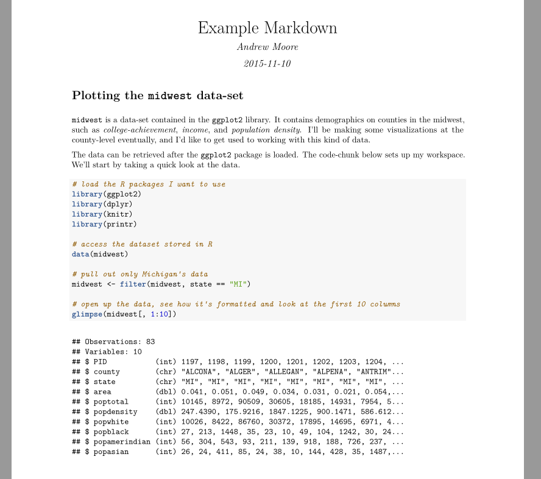

## R-Markdown as literate statistical programming

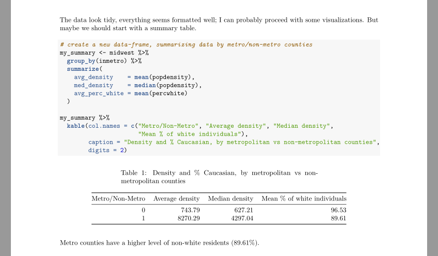

## Analyses/Manuscripts as "Recipes"

- Reproducibility an important subject overall, but has benefits even for those who work with sensitive files
- Good code/syntax allows you to reconstruct an analysis for yourself
- Storing local figures, data, summaries is a lot of cognitive overhead
- Markdown files encompass a product/report from start-to-finish
- Figures/tables are embedded in the output– no need to have a file of figures.